# Report: act_report

## Introduction

This is a data wrangling project that requires me to use Python and its libraries, to gather data from a variety of sources and in a variety of formats, assess its quality and tidiness, then clean it. Then document the wrangling efforts in a Jupyter Notebook, and showcase them through analyses and visualizations using Python (and its libraries) and/or SQL.

This report communicates all the insights and displays the visualization(s) produced from my wrangled data.

## Analyzing and Visualizing The Data

This report describe four insights from the analysis of the data and two visualizations.

### Insights:

1. What are most dogs called in the WeRateDogs archive?
2. What are the most popular dog breeds in the WeRateDogs archive?
3. Do the the most popular dog breeds have the highest ratings in the WeRateDogs archive?
4. Which dog breeds have the most likes and what are their retweet_counts on average?

#### Insight 1: The most popular dog names

To know the most popular dog names in our dataset

- I did a value count of the different names in the name column.
- I discovered that the most popular dog names were Charlie, Oliver, Cooper, Lucy, Penny, Tucker, etc.

```python
# Let's see the 20 most popular dog names in our DataFrame
twitter_archive_master.name.value_counts().head(20)
```

```
Charlie    11
Oliver     10
Cooper     10
Lucy       10
Penny       9
Tucker      9
Sadie       8
Winston     8
Toby        7
Daisy       7
Lola        7
Koda        6
Jax         6
Stanley     6
Bella       6
Bo          6
Oscar       5
Bailey      5
Scout       5
Rusty       5
Name: name, dtype: int64
```

#### Insight 2: The most popular dog breeds

To know the most popular dog breeds in our dataset

- I did a value count of the different breed names in the breed_prediction column.
- I discovered that the most popular dog breeds were Golden Retriever, Labrador Retriever, Pembroke, Chihuahua, Pug, Toy Poodle, etc.

```python
# Let's see the 20 most popular dog breeds in our DataFrame
twitter_archive_master.breed_prediction.value_counts().head(20)
```

```
Golden Retriever             156
Labrador Retriever           106
Pembroke                      94
Chihuahua                     90
Pug                           62
Toy Poodle                    50
Chow                          48
Samoyed                       42
Pomeranian                    41
Malamute                      33
French Bulldog                31
Chesapeake Bay Retriever      31
Cocker Spaniel                30
Miniature Pinscher            24
Eskimo Dog                    22
German Shepherd               21
Cardigan                      21
Siberian Husky                20
Beagle                        20
Staffordshire Bullterrier     20
Name: breed_prediction, dtype: int64
```

#### Insight 3: Do the most popular dog breeds have the highest ratings in the WeRateDogs archive?

To answer this question,

- I grouped the count of breed_prediction and mean rating by the breed_prediction column,
- firstly, I sorted by breed_counts in descending order to see the most popular breeds,
- then, I sorted by the mean_ratings in descending order to see the most highly rated breeds.
- I saw that most of the highly rated breeds where not among the most popular breeds.
- This immplies that the ratings does not determine the popularity and is not also dependent on it.

#### Insight 4: Which dog breeds have the most likes and what are their retweet_counts on average?

To know the dog breeds in our dataset with the most likes and their average retweet_counts,

- I grouped the sum of favorite_count and the sum of retweet_count by the breed_prediction column
- Then I sorted by the likes in descending order.
- I was able to see that the dog breeds with the highest likes, had the highest average retweet_counts and they were also the most popular dog breeds.

### Visualization

I ploted the top 20 breeds based on likes (using the insight 4 data), to see the relationship between the likes and retweet_counts.

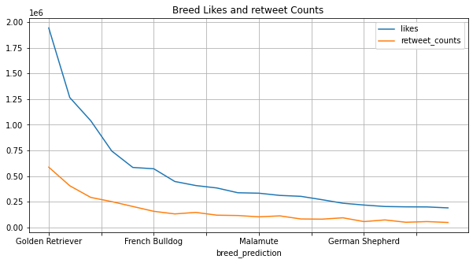

I saw that the breeds with very high likes also had large number of retweets and were also the most popular dog breeds.

Then I ploted the whole insight 4 data (I4), to be sure tha the relationship between the likes and retweet_counts is not perculiar to the top 20 rows alone but the same all through the dataset.

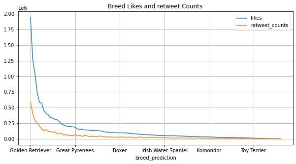

The relationship is consistent through out the dataset, this means that the higher the likes, the higher the retweets. It shows that the most popular dog breeds are the ones people talk about the most.

Then I decided to see what the most popular dog breed look like.

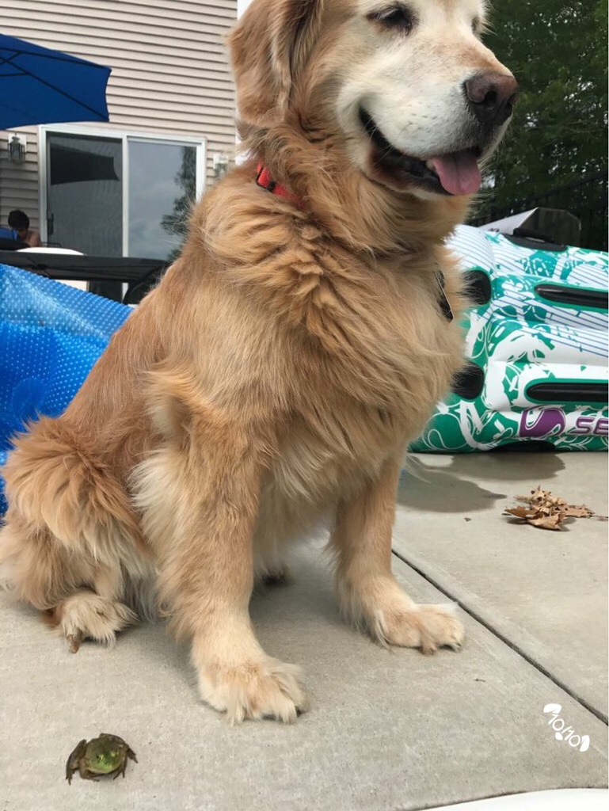

The Golden Retriever is a Scottish breed of retriever dog of medium size, characterised by a gentle and affectionate nature and a striking golden coat. They are smart, loyal dogs that are ideal family companions and with their gentle nature, shining coats, and charming smiles they are commonly kept as a pet. No wonder the are the most popular breeds in the Twitter WeRateDogs archive.